# Nonparametric Statistics Simulation

# 前言

### 主軸｜

比較有母數檢定與無母數檢定的差異。

### 有母數統計｜

已知母體分配形式（通常假設已知母體為常態分配），僅有幾個未知待推論的母數。

### 無母數統計｜

最大特色為分配自由化，不必假設母體分配為任何特定分配，故對於任意母數分配而言，非母數統計方法皆適用。

### 目的｜

透過模擬幫助未來判斷應用何種方式進行檢定。

# 文獻回顧

- 文獻提及t-test對於母體常態分配假設相當穩健（robust），即便母體稍有偏離常態分配，t-test仍然適用。
- 縱然檢定方法對於某些前提假設條件背離時仍穩健，只能保證型一錯誤率約略與我們所設定的顯著水準相去不遠，但並不保證此檢定方法的檢定力仍強，故從檢定力的觀點而言，母數方法的前提假設若不能滿足（尤其是母數常態的假設），應考慮檢定力較強的無母數方法。

| 差異 | 有母數統計 | 無母數統計 |
| --- | --- | --- |
| 統計推論對象 | 推論母數，如：期望值、變異數 | 直接推論母體分配型態本身或母體分配位置，而不透過母數 |
| 適用之變數資料型態 | 屬量變數為主 | 類別變數或順序等級，屬量變數應分組成類別變數或排序成順序等級 |
| 所需前提假設 | 較強，通常假定常態分配或大樣本 | 較少，不用假定母體為特定分配 |
| 適用範圍 | 假設多、較嚴格，應用於較少的問題上 | 假設少，可應用於較廣的問題 |
| 檢定力 | 母體分配滿足母數方法中的特定假設時，檢定力較強 | 母體分配不滿足母數方法中的特定假設時，檢定力較強 |
| 特色 | 母體分配偏離常態、更瘦尾（lighter tail），如均勻分配或問卷調查一至五的選項之分配，t-test不但穩健，其檢定力仍強 | 母體分配偏離常態、更肥尾（heavier tail），如指數分配、對數常態、卡方分配、有嚴重離群值存在的情況下無母數方法檢定力較強 |

A heavy tailed distribution has a tail that’s heavier than an exponential distribution (Bryson, 1974).

# 研究方法

## 選擇檢定

Ho: $\mu_1=\mu_2$

Ha: $\mu_1\neq\mu_2$

$\alpha=0.05$

## 觀察現象

控制顯著水準alpha下，比較

1. 不同母體
2. 不同樣本數

在有母數檢定與無母數檢定的檢定力（power）

補充說明：

需要建立公平的比較基準

在比較兩個方法的Power時，我們需要在Ha為真的情況，也就是$\mu_1\neq\mu_2$。在設定$\mu_1\neq\mu_2$時，我們以$\mu_2-\mu_1=k$來調整。為了在不同Population之下公平的比較power, 我們的k值以標準差為衡量，從0.1倍標準差開始到一倍標準差，一次改變0.1倍標準差。

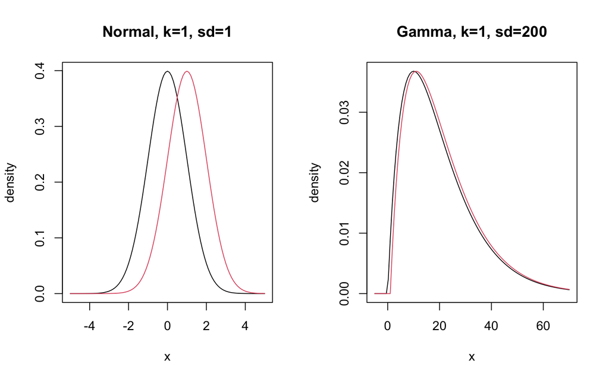

```r
par(mfrow=c(1,2))

curve(dnorm(x), from=-5, to=5, col=1,
      main="Normal, k=1, sd=1", ylab="density")
curve(dnorm(x, mean=0+1), from=-5, to=5, col=2, add=T)

curve(dgamma(x, 2, rate=0.1), from=-5, to=70, col=1,
      main="Gamma, k=1, sd=200", ylab="density")
curve(dgamma(x-1, 2, rate=0.1), from=-5, to=70, col=2, add=T)
```

## 選擇母體

### 1.Normal

有母數檢定：未違反假設

無母數檢定：未違反假設

### 2.Uniform

有母數檢定：違反假設（非常態需大樣本）

無母數檢定：未違反假設

### 3.Exponential

有母數檢定：違反假設（非常態需大樣本）

無母數檢定：未違反假設

### 4.Gamma

有母數檢定：違反假設（非常態需大樣本）

無母數檢定：未違反假設

### 5.Gamma with different shape

#### 5.1 Gamma (small shape)

#### 5.2 Gamma (large shape)

有母數檢定：違反假設（非常態需大樣本）

無母數檢定：違反假設（兩者分配相同但位置不同）

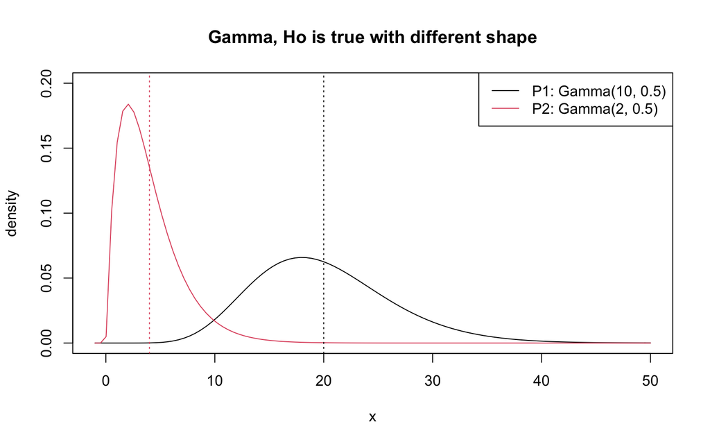

```r
# Gamma with different shape
# Ho is true
curve(dgamma(x, 10, rate=0.5), from=-1, to=50, col=1,
      main="Gamma, Ho is true with different shape", ylab="density", ylim=c(0,0.2))
curve(dgamma(x, 2, rate=0.5), from=-1, to=50, col=2, add=T)
legend("topright", c("P1: Gamma(10, 0.5)","P2: Gamma(2, 0.5)"),
       col=c(1,2), lty=1)
abline(v=20, col=1, lty=3)
abline(v=4, col=2, lty=3)
```

Gamma的偏態係數為2/sqrt(shape)，alpha越小越偏

```r
2/sqrt(10) # Gamma(10, 0.5)
```

```
## [1] 0.6324555
```

```r
2/sqrt(2) # Gamma(2, 0.5)
```

```
## [1] 1.414214
```

## 模擬步驟

1. 觀察不同分配之PDF, QQ plot
2. 生成隨機樣本
3. 進行檢定
4. 確定alpha穩定
5. 比較power

# 研究結果

Install packages

```r
library(randtests)
library(RVAideMemoire)
library(ggplot2)
library(reshape2)
```

## 建立函式

tail (method, n=10000, mean=0, sd=1, a=0, b=1, shape=2, rate=0.5, plot=F)

```r
tail <- function(method,n=10000, mean=0, sd=1, a=0, b=1, shape=2, rate=0.5, plot=F) {
  x<-c()
      if (method=="Normal"){
        x<-rnorm(n)
      }
      else if (method=="Uniform"){
        x<-runif(n, min=a, max=b)
      }
      else if (method=="Exp"){
        x<-rexp(n, rate=rate)
      }
      else if (method=="Gamma"){
        x<-rgamma(n, shape=shape, rate=rate)
      }
      else {
        print("Error")
        break
      }
  qqnorm(x)
  qqline(x)
}
```

alpha (method, B, n=10, mean=0, sd=1, a=0, b=1, shape=2, rate=0.5, plot=F)

```r
# method = Normal, Uniform, Exp, Gamma
alpha <- function(method, B, n=10, mean=0, sd=1, a=0, b=1, shape=2, rate=0.5, plot=F) {
  alpha<-0.05
  x<-c()
  y<-c()
  t.pv<-c()
  Wilcox.pv<-c()
  alpha_t<-c()
  alpha_Wilcox<-c()

  for(j in 1:length(B)){
    for(i in 1:B[j]){
      if (method=="Normal"){
        x<-rnorm(n)
        y<-rnorm(n)
      }
      else if (method=="Uniform"){
        x<-runif(n, min=a, max=b)
        y<-runif(n, min=a, max=b)
      }
      else if (method=="Exp"){
        x<-rexp(n, rate=rate)
        y<-rexp(n, rate=rate)
      }
      else if (method=="Gamma"){
        x<-rgamma(n, shape=shape, rate=rate)
        y<-rgamma(n, shape=shape, rate=rate)
      }
      else {
        print("Error")
        break
      }
      myt<-t.test(x,y)
      t.pv[i]<-myt$p.value
      Wilcox.pv[i] <- wilcox.test(x, y, exact = FALSE)$p.value
    }
    alpha_t[j] <- mean(t.pv<alpha)
    alpha_Wilcox[j]<-mean(Wilcox.pv<alpha)
  }
  if (plot==T){
    plot(x=B, y=alpha_t, ylim=c(0, 0.2), ylab="alpha",
         main=as.character(method), pch=16, col=2)
    points(x=B, y=alpha_Wilcox, pch=16, col=3)
    abline(h=0.05)
    legend("topright", c("T-test","Wilcoxon"), col=c(2,3), pch=16)
  }
}
```

kgen (v)

```r
kgen <- function(v){
    kgen <- c()
    for (i in 1:10){
      kgen[i] <- 0.1*i*v
    }
    return(kgen)
}
```

normal_power (n, B, v)

```r
# Normal
normal_power <- function(n, B, v) {
  alpha<-0.05
  t.pv<-c()
  Wilcox.pv<-c()
  k<-kgen((v)^(1/2))
  power_t<-data.frame(n10=c(rep(0,length(k))),n30=c(rep(0,length(k))))
  power_Wilcox<-data.frame(n10=c(rep(0,length(k))),n30=c(rep(0,length(k))))
  for(l in 1:length(n)){
    for(j in 1:length(k)){
      for(i in 1:B){
        x<-rnorm(n[l])
        y<-rnorm(n[l],mean=0+k[j])
        myt<-t.test(x,y)
        t.pv[i]<-myt$p.value
        Wilcox.pv[i] <- wilcox.test(x, y, exact = FALSE)$p.value
      }
      power_t[j,l] <- mean(t.pv<alpha)
      power_Wilcox[j,l]<-mean(Wilcox.pv<alpha)
    }
  }

  par(mfrow=c(1,2))
  require(ggplot2)
  require(reshape2)
  df <- data.frame(k = k,ttest = power_t,wilcoxtest = power_Wilcox)
  df <- melt(df ,  id.vars = 'k', variable.name = 'method')
  df$color=c(rep("t test",times=20),rep("wilcox test",times=20))
  df$shape=rep(c(rep("n=10",times=10),rep("n=30",times=10)),times=2)
  qplot(data = df,
          y = value,
          x = k, color=color,ylim=c(0,1),
          main=paste('N(0,1) with different k, B=',B,sep=""),
          ylab = "power")+geom_point(aes(shape=shape),size=3)
}
```

unif_power (n, B, a, b)

```r
# Uniform
unif_power <- function(n, B, a, b) {
  alpha<-0.05
  t.pv<-c()
  Wilcox.pv<-c()
  k<-kgen((((b-a)^2)/12)^(1/2))
  power_t<-data.frame(n10=c(rep(0,length(k))),n30=c(rep(0,length(k))))
  power_Wilcox<-data.frame(n10=c(rep(0,length(k))),n30=c(rep(0,length(k))))
  for(l in 1:length(n)){
    for(j in 1:length(k)){
      for(i in 1:B){
        x<-runif(n[l], a, b)
        y<-runif(n[l], min=a+k, max=k[j]+b)
        myt<-t.test(x,y)
        t.pv[i]<-myt$p.value
        Wilcox.pv[i] <- wilcox.test(x, y, exact = FALSE)$p.value
      }
      power_t[j,l] <- mean(t.pv<alpha)
      power_Wilcox[j,l]<-mean(Wilcox.pv<alpha)
    }
  }
  par(mfrow=c(1,2))
  require(ggplot2)
  require(reshape2)
  df <- data.frame(k = k,ttest = power_t,wilcoxtest = power_Wilcox)
  df <- melt(df ,  id.vars = 'k', variable.name = 'method')
  df$color=c(rep("t test",times=20),rep("wilcox test",times=20))
  df$shape=rep(c(rep("n=10",times=10),rep("n=30",times=10)),times=2)
  qplot(data = df,
          y = value,
          x = k, color=color,ylim=c(0,1),
          main=paste('Unif(a=',a,', b=',b,') with different k, B=',B,sep=""),
          ylab = "power")+geom_point(aes(shape=shape),size=3)
}
```

exp_power (n, B, b)

```r
# Exp
# b is rate
exp_power <- function(n, B, b) {
  alpha<-0.05
  t.pv<-c()
  Wilcox.pv<-c()
  k<-kgen((1*(b^-2))^(1/2))
  power_t<-data.frame(n10=c(rep(0,length(k))),n30=c(rep(0,length(k))))
  power_Wilcox<-data.frame(n10=c(rep(0,length(k))),n30=c(rep(0,length(k))))
  for(l in 1:length(n)){
    for(j in 1:length(k)){
      for(i in 1:B){
        x<-rgamma(n[l],shape =1 ,rate = b)
        x<-x+k[j]
        y<-rgamma(n[l],shape =1 ,rate = b)
        myt<-t.test(x,y)
        t.pv[i]<-myt$p.value
        Wilcox.pv[i]<-wilcox.test(x, y, exact = FALSE)$p.value
      }
      power_t[j,l]<-mean(t.pv<alpha)
      power_Wilcox[j,l]<-mean(Wilcox.pv<alpha)
    }
  }
  par(mfrow=c(1,2))
  require(ggplot2)
  require(reshape2)
  df <- data.frame(k = k,ttest = power_t,wilcoxtest = power_Wilcox)
  df <- melt(df ,  id.vars = 'k', variable.name = 'method')
  df$color=c(rep("t test",times=20),rep("wilcox test",times=20))
  df$shape=rep(c(rep("n=10",times=10),rep("n=30",times=10)),times=2)
  qplot(data = df,
          y = value,
          x = k, color=color,ylim=c(0,1),
          main=paste('Exp(rate=',b,') with different k, B=',B,sep=""),
          ylab = "power")+geom_point(aes(shape=shape),size=3)
}
```

gamma_power (n, B, a, b)

```r
# Gamma
gamma_power <- function(n, B, a, b) {
  alpha<-0.05
  t.pv<-c()
  Wilcox.pv<-c()
  k<-kgen((a*(b^-2))^(1/2))
  power_Wilcox<-data.frame(n10=c(rep(0,length(k))),n30=c(rep(0,length(k))))
  power_t<-data.frame(n10=c(rep(0,length(k))),n30=c(rep(0,length(k))))
  for(l in 1:length(n)){
    for(j in 1:length(k)){
      for(i in 1:B){
        x<-rgamma(n[l],shape =a ,rate = b)
        y<-x+k[j]
        myt<-t.test(x,y)
        t.pv[i]<-myt$p.value
        Wilcox.pv[i] <- wilcox.test(x, y, exact = FALSE)$p.value
      }
      power_t[j,l] <- mean(t.pv<alpha)
      power_Wilcox[j,l]<-mean(Wilcox.pv<alpha)
    }
  }
  par(mfrow=c(1,2))
  require(ggplot2)
  require(reshape2)
  df <- data.frame(k = k,ttest = power_t,wilcoxtest = power_Wilcox)
  df <- melt(df ,  id.vars = 'k', variable.name = 'method')
  df$color=c(rep("t test",times=20),rep("wilcox test",times=20))
  df$shape=rep(c(rep("n=10",times=10),rep("n=30",times=10)),times=2)
  qplot(data = df,
          y = value,
          x = k, color=color,ylim=c(0,1),
          main=paste('Gamma(shape=',a,', rate=',b,') with different k, B=',B,sep=""),
          ylab = "power")+geom_point(aes(shape=shape),size=3)
}
```

gamma_diff_shape_power (n, B, a, b)

```r
# Gamma change shape (different meaning of k!!)
gamma_diff_shape_power <- function(n, B, a, b) {
  alpha<-0.05
  t.pv<-c()
  Wilcox.pv<-c()
  k<-seq(0.1,3,0.3)
  power_Wilcox<-data.frame(n10=c(rep(0,length(k))),n30=c(rep(0,length(k))))
  power_t<-data.frame(n10=c(rep(0,length(k))),n30=c(rep(0,length(k))))
  for(l in 1:length(n)){
    for(j in 1:length(k)){
      for(i in 1:B){
        x<-rgamma(n[l],shape =a ,rate = b)
        y<-rgamma(n[l],shape =a+k[j] ,rate = b)
        myt<-t.test(x,y)
        t.pv[i]<-myt$p.value
        Wilcox.pv[i] <- wilcox.test(x, y, exact = FALSE)$p.value
      }
      power_t[j,l] <- mean(t.pv<alpha)
      power_Wilcox[j,l]<-mean(Wilcox.pv<alpha)
    }
  }
  par(mfrow=c(1,2))
  require(ggplot2)
  require(reshape2)
  df <- data.frame(k = k,ttest = power_t,wilcoxtest = power_Wilcox)
  df <- melt(df ,  id.vars = 'k', variable.name = 'method')
  df$color=c(rep("t test",times=20),rep("wilcox test",times=20))
  df$shape=rep(c(rep("n=10",times=10),rep("n=30",times=10)),times=2)
  qplot(data = df,
          y = value,
          x = k, color=color,ylim=c(0,1),
          main=paste('Gamma(shape=',a,', rate=',b,') with different k, B=',B,sep=""),
          ylab = "power")+geom_point(aes(shape=shape),size=3)
}
```

## Shift Normal

有母數檢定：未違反假設

無母數檢定：未違反假設

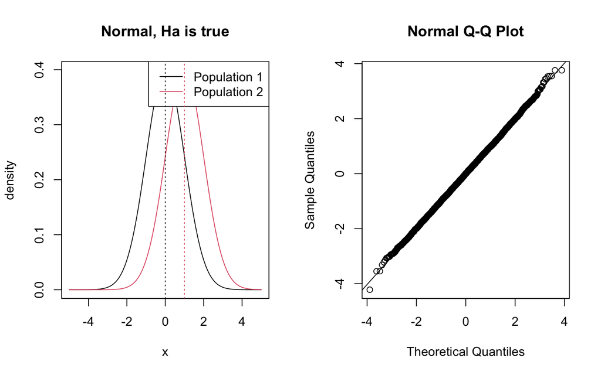

```r
par(mfrow=c(1,2))

curve(dnorm(x), from=-5, to=5, col=1,
      main="Normal, Ha is true", ylab="density")
curve(dnorm(x, mean=0+1), from=-5, to=5, col=2, add=T)
legend("topright", c("Population 1","Population 2"),
       col=c(1,2), lty=1)
abline(v=0, col=1, lty=3)
abline(v=1, col=2, lty=3)

tail(method = "Normal")
```

alpha

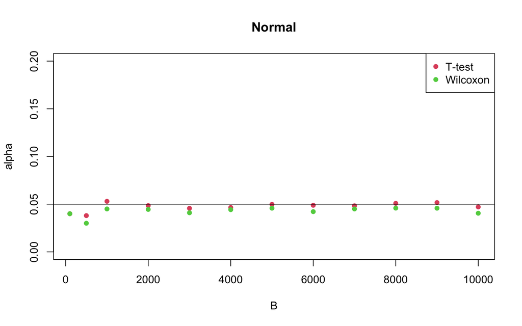

```r
n<-10
B<-c(100,500,seq(1000,10000,1000))
alpha("Normal", n=n, B=B, mean=0, sd=1, plot=T)
```

power

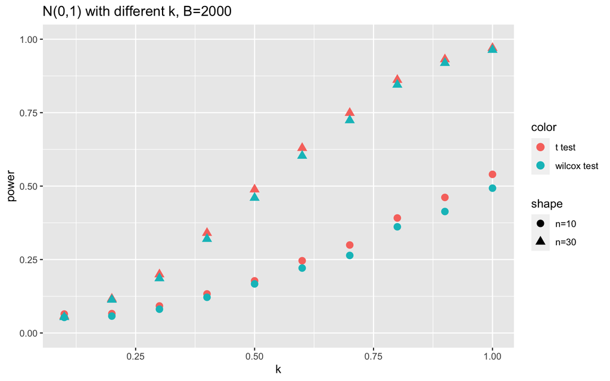

```r
normal_power(n=c(10,30), B=2000, v=1)
```

## Shift Uniform

有母數檢定：違反假設（非常態需大樣本）

無母數檢定：未違反假設

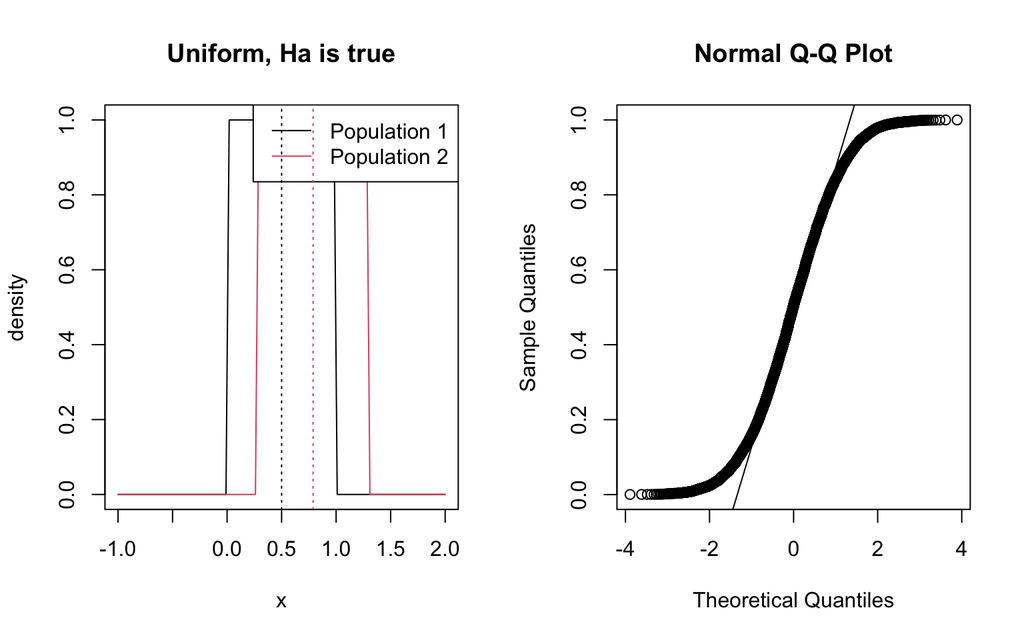

```r
par(mfrow=c(1,2))

curve(dunif(x, 0, 1), from=-1, to=2, col=1,
      main="Uniform, Ha is true", ylab="density")
curve(dunif(x, 0+0.2886751, 1+0.2886751), from=-1, to=2, col=2, add=T)
legend("topright", c("Population 1","Population 2"),
       col=c(1,2), lty=1)
abline(v=0.5, col=1, lty=3)
abline(v=0.7886751, col=2, lty=3)

tail(method = "Uniform")
```

alpha

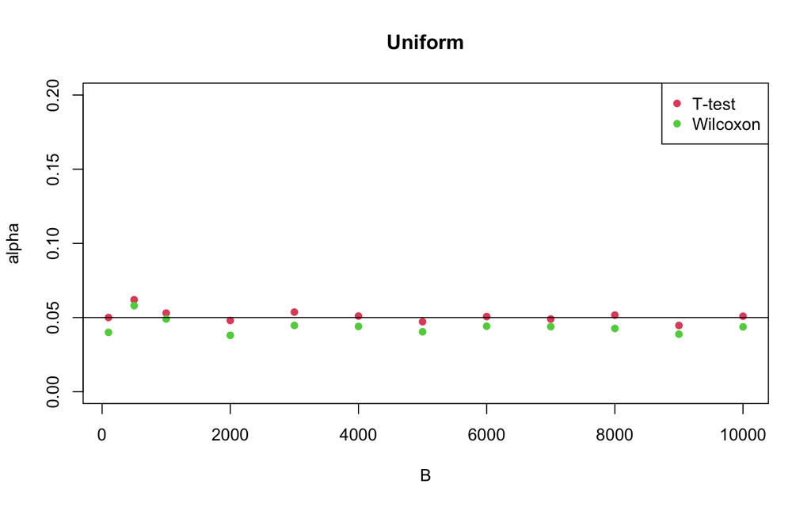

```r
n<-10
B<-c(100,500,seq(1000,10000,1000))
alpha("Uniform", n=n, B=B, a=0, b=1, plot=T)
```

power

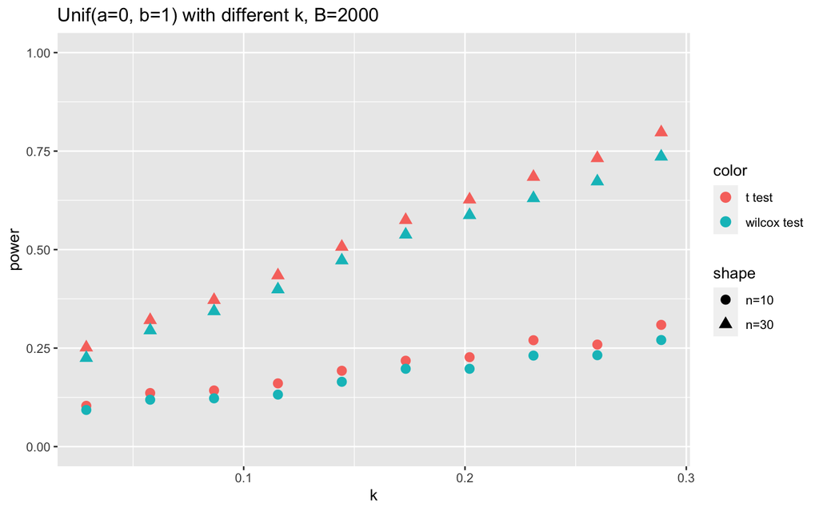

```r
unif_power(n=c(10,30), B=2000, a=0, b=1)
```

## Shift Exponential

有母數檢定：違反假設（非常態需大樣本）

無母數檢定：未違反假設

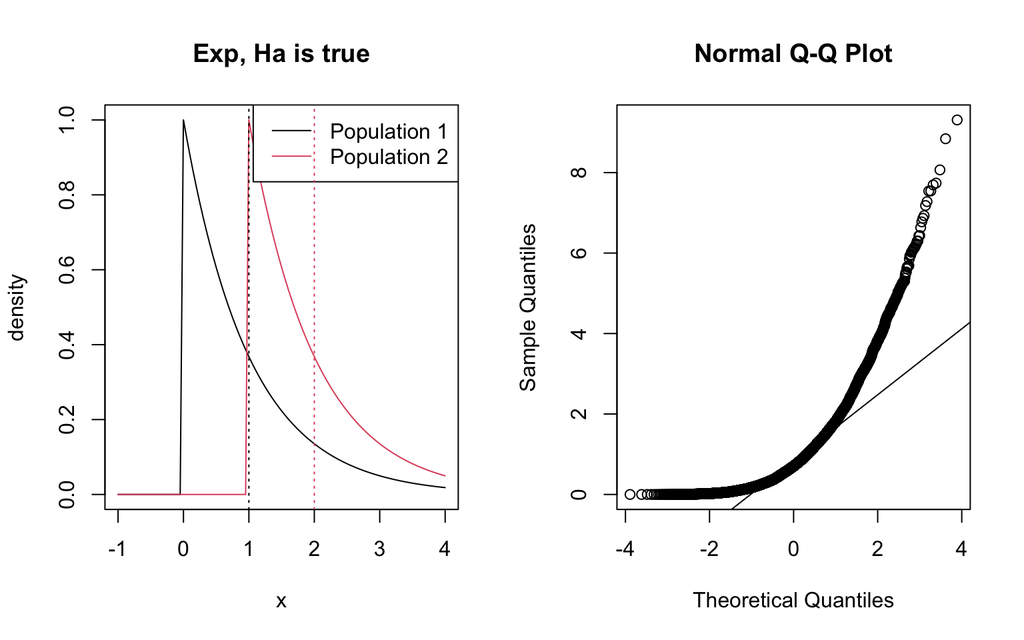

```r
par(mfrow=c(1,2))

curve(dexp(x, 1), from=-1, to=4, col=1,
      main="Exp, Ha is true", ylab="density")
curve(dexp(x-1, 1), from=-1, to=4, col=2, add=T)
legend("topright", c("Population 1","Population 2"),
       col=c(1,2), lty=1)
abline(v=1, col=1, lty=3)
abline(v=2, col=2, lty=3)

tail(method = "Exp", rate = 1)
```

```r
n<-10
B<-c(100,500,seq(1000,10000,1000))
alpha("Exp", n=n, B=B, rate=1)
```

power

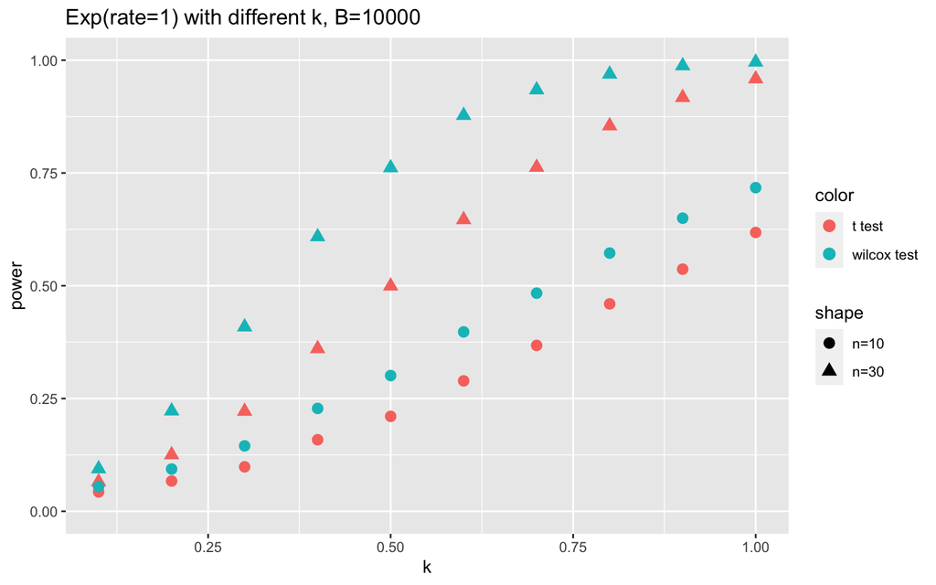

```r
exp_power(n=c(10,30), B=10000, b=1)
```

## Shift Gamma

有母數檢定：違反假設（非常態需大樣本）

無母數檢定：未違反假設

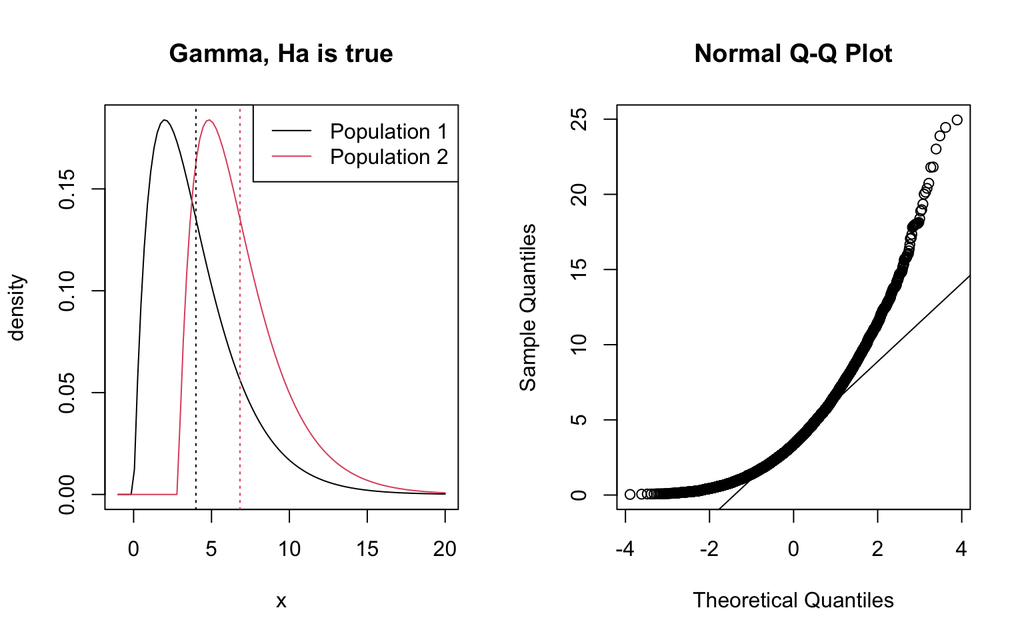

```r
par(mfrow=c(1,2))

curve(dgamma(x, 2, rate=0.5), from=-1, to=20, col=1,
      main="Gamma, Ha is true", ylab="density")
curve(dgamma(x-2.828427, 2, rate=0.5), from=-1, to=20, col=2, add=T)
legend("topright", c("Population 1","Population 2"),
       col=c(1,2), lty=1)
abline(v=4, col=1, lty=3)
abline(v=4+2.828427, col=2, lty=3)

tail(method = "Gamma")
```

alpha

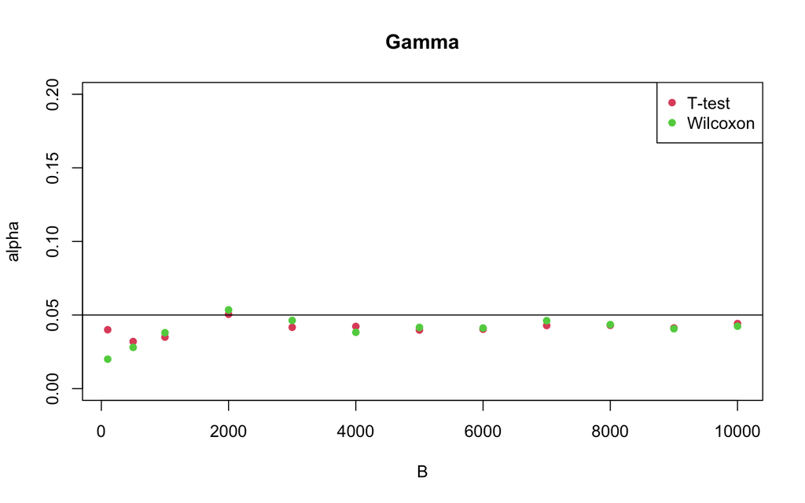

```r
n<-10
B<-c(100,500,seq(1000,10000,1000))
alpha("Gamma", n=n, B=B, shape=2, rate=0.5, plot=T)
```

power

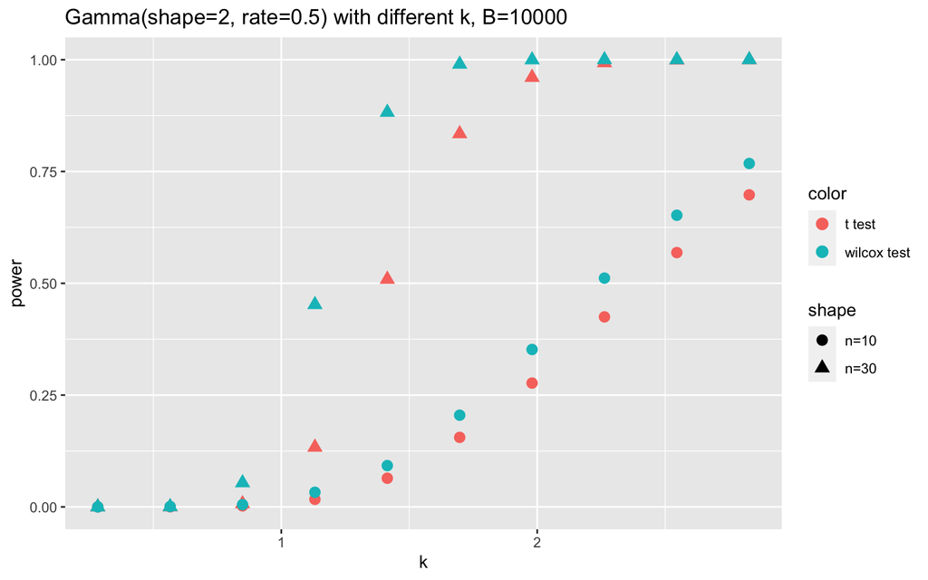

```r
gamma_power(n=c(10,30), B=10000, a=2, b=0.5)
```

## Gamma with different shape

有母數檢定：違反假設（非常態需大樣本）

無母數檢定：違反假設（兩者分配相同但位置不同）

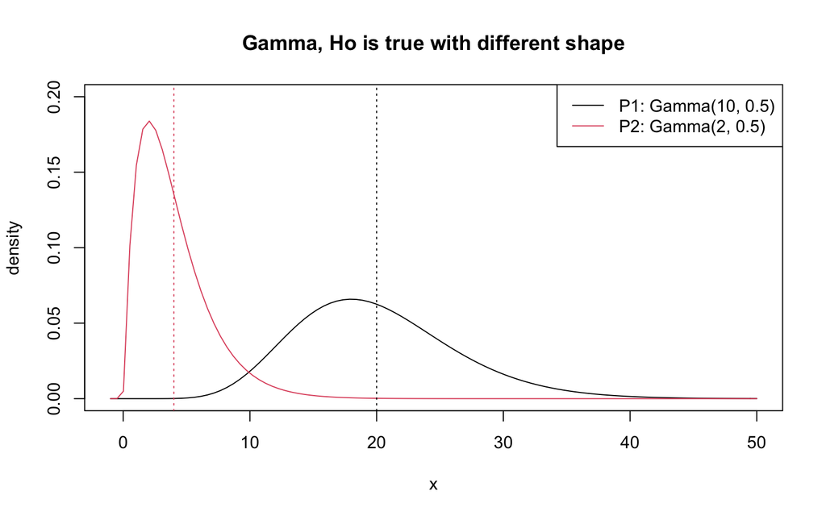

```r
curve(dgamma(x, 10, rate=0.5), from=-1, to=50, col=1,
      main="Gamma, Ho is true with different shape", ylab="density", ylim=c(0,0.2))
curve(dgamma(x, 2, rate=0.5), from=-1, to=50, col=2, add=T)
legend("topright", c("P1: Gamma(10, 0.5)","P2: Gamma(2, 0.5)"),
       col=c(1,2), lty=1)
abline(v=20, col=1, lty=3)
abline(v=4, col=2, lty=3)
```

### Gamma with different shape (small shape)

有母數檢定：違反假設（非常態需大樣本）

無母數檢定：違反假設（兩者分配相同但位置不同）

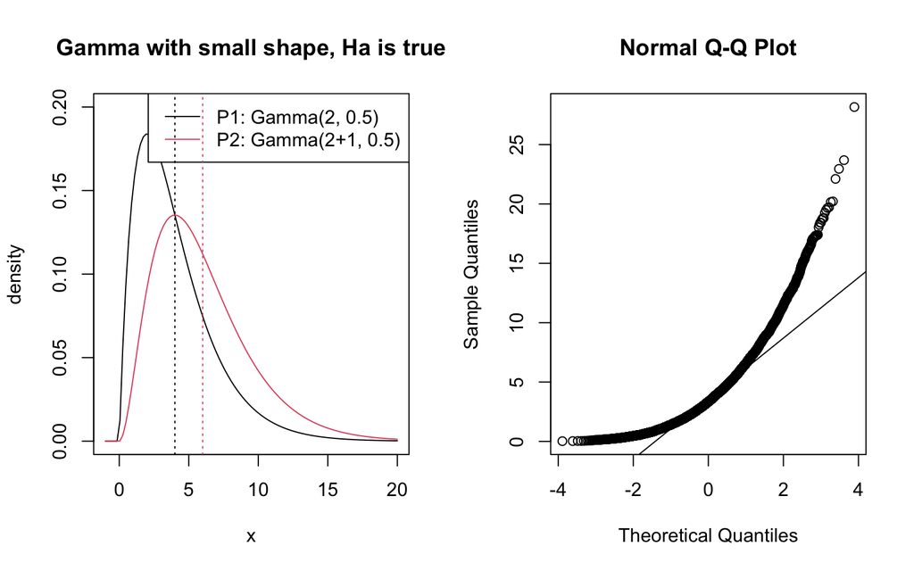

```r
par(mfrow=c(1,2))

curve(dgamma(x, 2, rate=0.5), from=-1, to=20, col=1,
      main="Gamma with small shape, Ha is true", ylab="density", ylim=c(0,0.2))
curve(dgamma(x, 2+1, rate=0.5), from=-1, to=20, col=2, add=T)
legend("topright", c("P1: Gamma(2, 0.5)","P2: Gamma(2+1, 0.5)"),
       col=c(1,2), lty=1)
abline(v=4, col=1, lty=3)
abline(v=6, col=2, lty=3)

tail(method = "Gamma", shape=2)
```

alpha

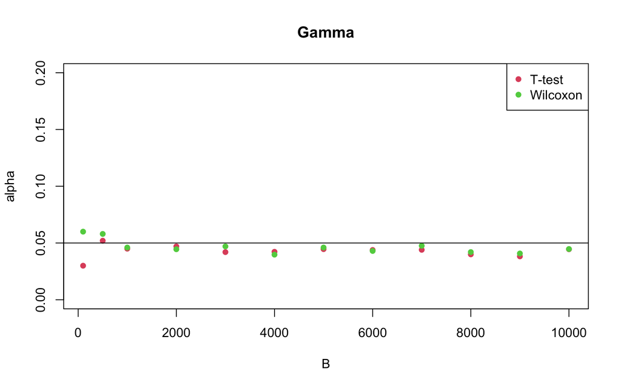

```r
n<-10
B<-c(100,500,seq(1000,10000,1000))
alpha("Gamma", n=n, B=B, shape=2, rate=0.5, plot=T)
```

power

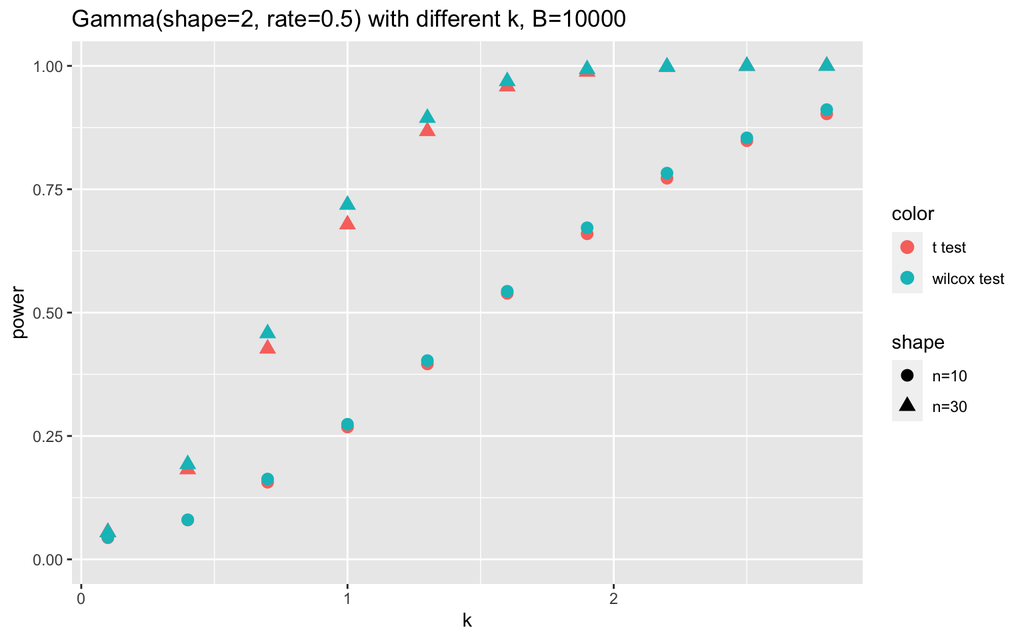

```r
gamma_diff_shape_power(n=c(10,30), B=10000, a=2, b=0.5)
```

### Gamma with different shape (large shape)

有母數檢定：違反假設（非常態需大樣本）

無母數檢定：違反假設（兩者分配相同但位置不同）

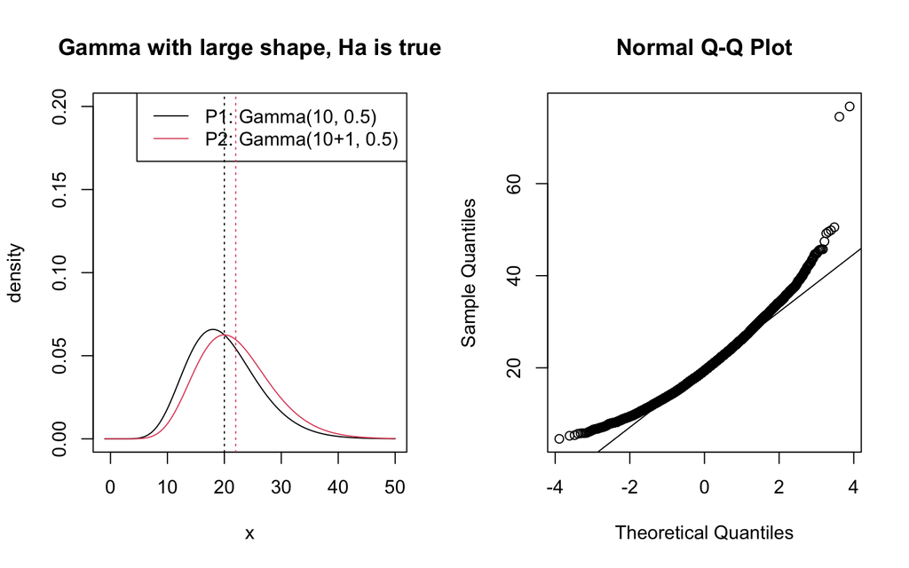

```r
par(mfrow=c(1,2))

curve(dgamma(x, 10, rate=0.5), from=-1, to=50, col=1,
      main="Gamma with large shape, Ha is true", ylab="density", ylim=c(0,0.2))
curve(dgamma(x, 10+1, rate=0.5), from=-1, to=50, col=2, add=T)
legend("topright", c("P1: Gamma(10, 0.5)","P2: Gamma(10+1, 0.5)"),
       col=c(1,2), lty=1)
abline(v=20, col=1, lty=3)
abline(v=22, col=2, lty=3)

tail(method = "Gamma", shape=10)
```

alpha

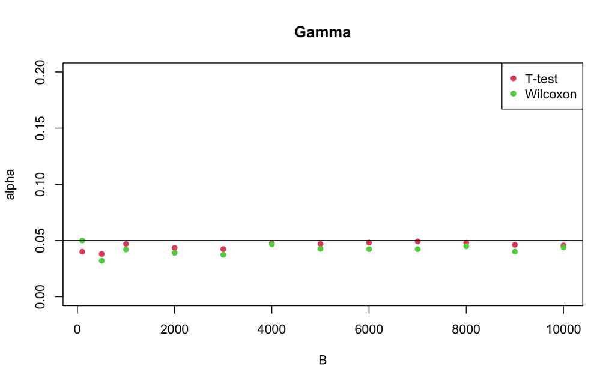

```r
n<-10
B<-c(100,500,seq(1000,10000,1000))
alpha("Gamma", n=n, B=B, shape=10, rate=0.5, plot=T)
```

power

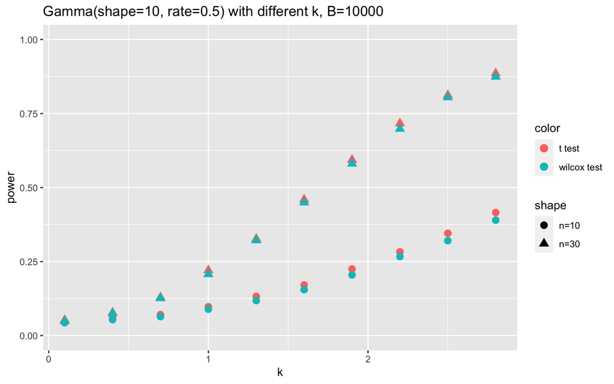

```r
gamma_diff_shape_power(n=c(10,30), B=10000, a=10, b=0.5)
```

# 結論

| 分配 | 特色 | 有母數檢定 T-test | 無母數檢定 Wilcoxon rank sum test |
| --- | --- | --- | --- |
| Normal | 對稱 | 勝 |  |
| Uniform | 對稱、瘦尾 | 勝 |  |
| Exponential | 肥尾 |  | 勝 |
| Gamma | 肥尾 |  | 勝 |
| Gamma (small shape) | 偏度較大 |  | 勝 |
| Gamma (large shape) | 偏度較小 | 勝 |  |

# 工作分配

侯登耀: 圖形繪製

劉貞莉: 挑選母體,報告統整,上台報告

周郁倫: 挑選母體,報告統整

張倢琳: 參數變化(n,k)

李佳璇: 圖形繪製

蕭 堯: 設計function,上台報告

譚昇雄: html製作

郭沛辰: 圖形繪製

韓伊晴: 參數變化(n,k)